# GEN-I: Nelinearne transakcije

Kratko porocilo

Anja Trobec

April 2022

## NAVODILA ZA IZDELAVO PROJEKTA

Imamo mesecno nelinearno transakcijo za elektricno energijo, kjer se lahko znotraj dolocenih omejitev za vsako uro znotraj meseca dobave lastnik opcijskosti odloci, koliko el. energije bo prevzeli/dobavil. Ovrednotimo jo napram mnozici cenovnih scenarijev, tako da za vsak cenovni scenarij dobimo njen profit. Cenovni scenariji so mozne prihodnje cene dobave, oblikovani tako, da ustrezno popisejo verjetnostno porazdelitev prihodnje cene v smislu njene srednje vrednosti in standardne deviacije (volatilnosit). Za to transakcijo zelimo poiskati njen ekvivalent standardne Evropske opcije. Kaksni so parametri ekvivalenta te opcije, kot kolicina, cena (strike), stran (nakup/prodaja) in tip (call/put) opcije?

## PROJEKT

### TEORETICNI UVOD

Moja naloga je poiskati Evropsko opcijo, ki najboljse opise transakcijo predstavljeni v podatkih. Vhodni podatki so pari, v katerih prva komponenta predstavlja ceno (*$S_t$* - *cena ob casu t*) in druga komponenta profit pri dani ceni (*$V_t$* - *vrednost opcije v casu t*). Cena je izrazena v EUR/MWh, profit pa v EUR.

$$(S_t,V_t)$$

Iskani Evropski opciji, ki bo ekvivalentna transakciji, je potrebno dolociti najslednje parametre:

- izvrsilno cena ($K$, *angl. strike price*),
- kolicino ($Q$) in
- placano ali prejeto premijo (*angl. option premium*).

Dolociti je potrebno tudi **tip opcije**. Lahko gre za:

- **nakupno opcijo** (*angl. call option*) ali
- **prodajno opcijo** (*angl. put option*).

Znotraj obeh tipov opcij, locimo se dve poziciji, kateri lahko zavzamemo. Lahko smo v vlogi izdajatelja opcije (*angl. option writer*) in v tem primeru **opcijo prodamo** ali pa **opcijo kupimo** in s tem postanemo lastnik opcije (*angl. option buyer*).

To nas pripelje do stirih razlicnih situacij, med katerimi iscemo tisto, ki najbolje opise dano transakcijo.

OPOMBA: obravnavamo le Evropske opcije.

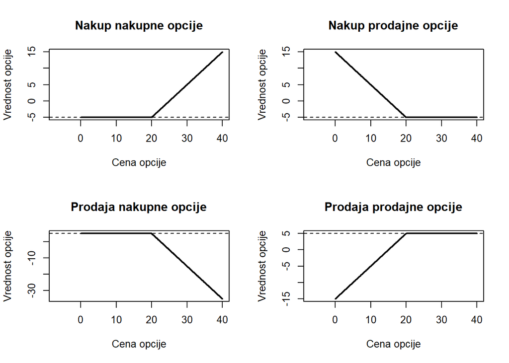

### PRISTOP K RESEVANJU PROBLEMA

Resevanja problema se je najbolj smiselno lotiti na nacin, da vhodne podatke graficno upodobimo. V nekaterih primerih bo ze iz zacetne slike jasno, katero izmed stirih situacij bomo uporabili za aproksimacijo.

Primer ‘jasne zacetne slike’ je prikazan na spodnjem grafu.

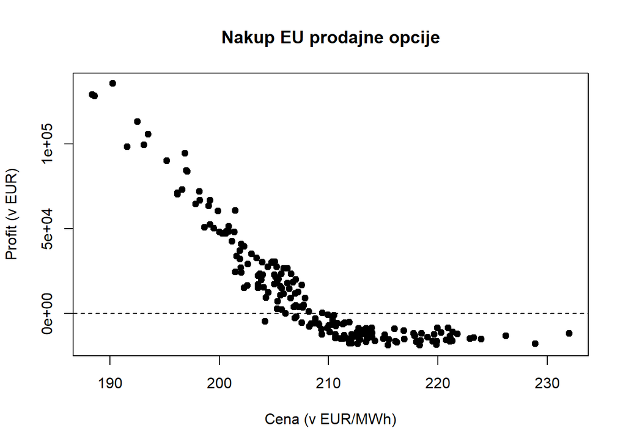

Hitro razberemo, da gre za **nakup evropske prodajne opcije**. Preostane nam le se dolocitev parametrov. Dolociti moramo izvrsilno ceno ($K$), kolicino ($Q$) in premijo (*premium*). Kako to najlazje storimo?

Ocitno je, da so vsi stirje tipi opcij sestavljeni iz dveh premic. Ena izmed premic je vselej vzporedna x osi, druga pa ima bodisi pozitiven bodisi negativen naklon. Ideja je, da **vsako vhodno transakcijo aproksimiramo s kombinacijo teh dveh premic**. S tem, ko dolocimo ustrezno kombinacijo premic, ugotovimo, za katero vrsto opcije in tip pozicije gre. Nadaljno lahko iz smernega koeficienta in zacetne vrednosti izbranih optimalnih premic, dolocimo iskane parametre.

Premica, ki bo vselej vodoravna doloca premijo (*opomba: premija je lahko negativna ali pozitivna*):
$$y = premija$$

Premica s pozitivnim ali negativnim naklonom doloca kolicino (Q):

$$y = Q * S_t + n$$

Iz presecisca zgornjih dveh premic dobimo izvrsilno ceno (K):

$$K = \frac{premija - n}{kolicina}$$

### ALGORITEM

Algoritem sprejme csv datoteko sestavljeno iz dveh stolpcev. V prvem stolpcu najdemo ceno financnega instrumenta izrazeno v EUR/MWh in v drugem stolpcu najdemo profit pri dani ceni, izrazen v EUR. Algoritem podatke prebere in takoj doloci, za kaksno vrsto opcije gre. To stori na naslednji nacin:

1. Algoritem **izracuna korelacijo** med podatki in s tem izbiro med stirimi moznostmi prevede na izbiro med spodnjima dvema:
- Ce je **korelacija negativna**, takoj vemo, da gre za *nakup prodajne opcije* ali za *prodajo nakupne opcije*.

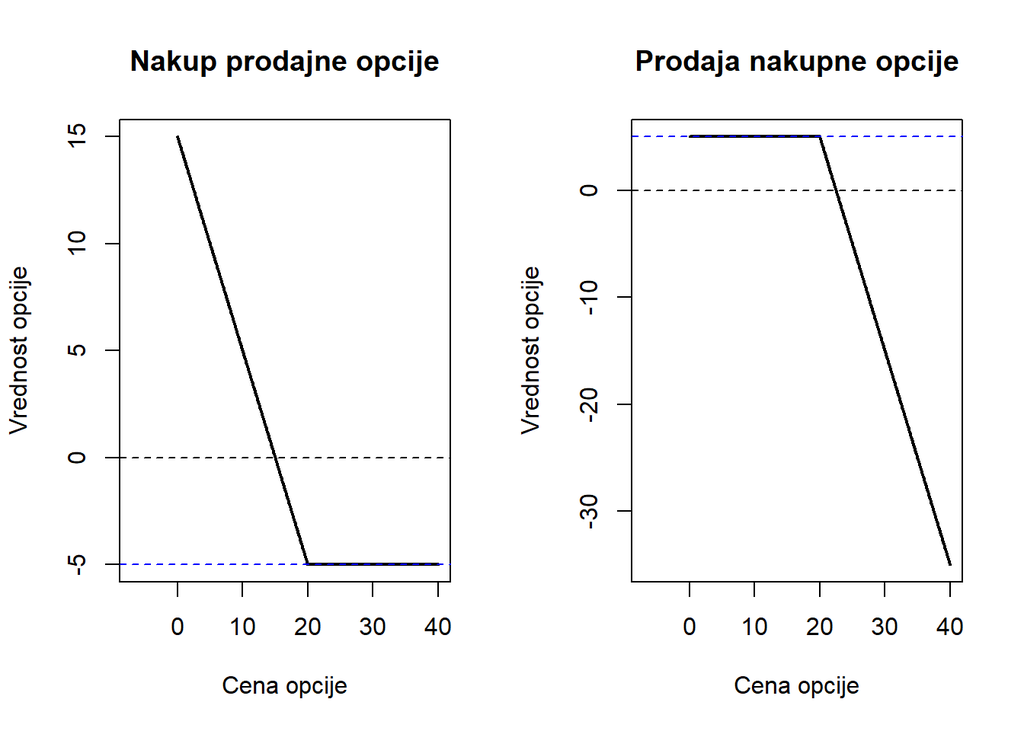

- Ce je **korelacija pozitivna**, pa nam preostaneta ali *prodaja prodajne opcije* ali pa *nakup nakupne opcije*.

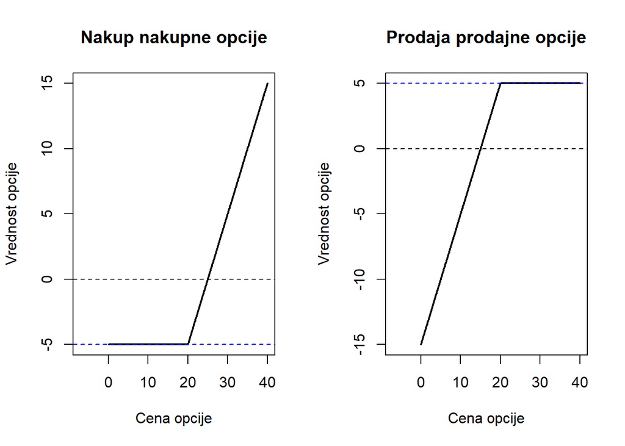

2. Na drugem koraku izbiramo le se med dvema moznostima. Odlocitev ali gre za nakupno ali prodajno opcijo sprejmemo na podlagi velikosti napake, ki se pojavi pri aproksimaciji z eno ali z drugo kombinacijo premic. Izbiramo torej med kombinacijama:
- prva premica bo vodoravna in druga z nenicelnim naklonom ali
- prva premica bo imela nenicelni naklon in druga bo vodoravna.

Z enostavno primerjavo napak smo nasli ustrezno obliko za aproksimacijo.

Opisani algoritem nam vrne:

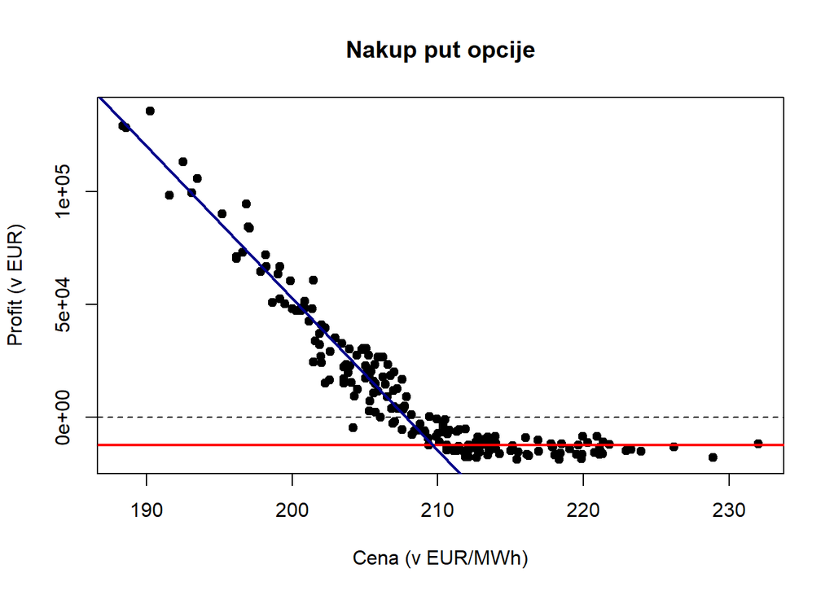

[output not shown]

### UGOTOVITVE IN NADALJNE DELO

Ocitno je, da linearna regresija vsaj na videz ni najboljsa resitev, ko iscemo optimalni fit. Trenutno delam na izboljsanju aproksimacije razprsenega dela podatkov. V koncnem porocilu bom predstavila aproksimacije tudi na drugih podatkih.

Ko bom z aproksimacijo povsem zadovoljna sem razmisljala o vzpostavitvi shiny aplikacije, ki bi sprejela csv datoteko, narisala graf in vrnila parametre iskane EU vanilla opcije. O se bolj zanimivih funkcijah aplikacije bom bolj razmisljala kasneje, ko bo glavni del naloge opravljen.

### KODA

```r
opt_fit <- function(price, profit){
  if (cor(price, profit) < 0){
    #nakup put opcije (3) ali prodaja nakupne opcije (2)

    #pogledamo napake odstopanj in odlocimo ali gre za put ali call
    meja <- length(price)/4
    povpr1 <- mean(profit[1:meja])
    er1 <- 0
    for (i in 1:meja){
      er1 <- er1 + (profit[i] - povpr1)^2}
    povpr1 <- mean(profit[(length(price)-meja):length(price)])
    er2 <- 0
    for (i in (length(price)-meja):length(price)){
      er2 <- er2 + (profit[i] - povpr1)^2}


    #1. NAKUP PUT OPCIJE__________________________________________________________
    if (er1 > er2){
      komentar <- paste("Gre za nakup put opcije.")
      print(komentar)

      odstopanje1 <- rep(0,length(price)) #odstopanje pri aproksimaciji z vodoravno premico
      odstopanje2 <- rep(0,length(price)) #odstopanje pri aproksimaciji z linearno regresijo (posevni del)
      najboljsi_K = 0


      #GLAVNA ZANKA
      for (K in 1:length(price)){
        #VODORAVNA PREMICA
        premica1 <- profit[K]
        napaka1 <- rep(0,length(price[K:length(profit)]))
        profiti <- profit[K:length(profit)]
        for (i in 1:length(napaka1)){
          napaka1[i] <- (((premica1 - profiti[i])^2))
        }
        odstopanje1[K] <- sum(napaka1)


        #POsEVNA PREMICA
        premica2 <- lm(profit[1:K] ~ price[1:K])
        odstopanje2[K] <- deviance(premica2)
        odstopanje2[K]
      }

      odstopanja <- odstopanje1 + odstopanje2

      najboljsi_K <- which(min(odstopanja) == odstopanja)
      premica1 <- mean(profit[najboljsi_K:length(profit)])
      abline(h = profit[najboljsi_K], col = 'red', lwd=2)
      premica2 <- lm(profit[1:najboljsi_K] ~ price[1:najboljsi_K])
      abline(premica2$coefficients[1],premica2$coefficients[2], col = 'dark blue',lwd=2)
      najboljsi_K
      #points(price[najboljsi_K], profit[najboljsi_K],type = "p", col = "green")

      strike_price = round(price[najboljsi_K],3)
      premija = round(profit[najboljsi_K],3)
      komentar <- paste("Priblizek za izvrsilno ceno opcije je ", as.character(strike_price), ", za premijo pa ", as.character(premija), ".",sep="")
      print(komentar)

    }

    #PRODAJA CALL OPCIJE__________________________________________________________

    if (er2 > er1){
      komentar <- paste("Gre za prodajo call opcije.")
      print(komentar)

      odstopanje1 <- rep(0,length(price)) #odstopanje pri aproksimaciji z vodoravno premico
      odstopanje2 <- rep(0,length(price)) #odstopanje pri aproksimaciji z linearno regresijo (posevni del)
      najboljsi_K = 0

      for (K in 1:length(price)){
        #VODORAVNA PREMICA
        premica1 <- mean(profit[1:K])
        napaka1 <- rep(0,length(price[1:K]))
        for (i in 1:length(napaka1)){
          napaka1[i] <- (((premica1 - profit[i])^2))
        }
        odstopanje1[K] <- sum(napaka1)


        #POsEVNA PREMICA
        premica2 <- lm(profit[K:length(price)] ~ price[K:length(price)])
        odstopanje2[K] <- deviance(premica2)
        odstopanje2[K]
      }

      odstopanja <- odstopanje1 + odstopanje2
      najboljsi_K <- which(min(odstopanja) == odstopanja)
      premica1 <- profit[najboljsi_K]
      abline(h = profit[najboljsi_K], col = 'red', lwd=2)
      premica2 <- lm(profit[najboljsi_K:length(price)] ~ price[najboljsi_K:length(price)])
      abline(premica2$coefficients[1],premica2$coefficients[2], col = 'dark blue', lwd=2)
      najboljsi_K
      #points(price[najboljsi_K], profit[najboljsi_K],type = "p", col = "green")

      strike_price = round(price[najboljsi_K],3)
      premija = round(profit[najboljsi_K],3)
      komentar <- paste("Priblizek za izvrsilno ceno opcije je ", as.character(strike_price), ", za premijo pa ", as.character(premija), ".",sep="")
      print(komentar)
    }
  }

  if (cor(price, profit) > 0){
    #nakup call opcije ali prodaja put opcije

    meja <- length(price)/4
    povpr1 <- mean(profit[1:meja])
    er1 <- 0

    for (i in 1:meja){
      er1 <- er1 + (profit[i] - povpr1)^2
    }

    povpr1 <- mean(profit[(length(price)-meja):length(price)])
    er2 <- 0
    for (i in (length(price)-meja):length(price)){
      er2 <- er2 + (profit[i] - povpr1)^2
    }

    #PRODAJA PUT OPCIJE__________________________________________________________
    if (er1 > er2){
      komentar <- paste("Gre za prodajo put opcije.")
      print(komentar)

      #poiscimo optimalni fit
      odstopanje1 <- rep(0,length(price)) #odstopanje pri aproksimaciji z vodoravno premico
      odstopanje2 <- rep(0,length(price)) #odstopanje pri aproksimaciji z linearno regresijo (posevni del)
      najboljsi_K = 0


      for (K in 1:length(price)){
        #VODORAVNA PREMICA
        premica1 <- mean(profit[K:length(profit)])
        napaka1 <- rep(0,length(price[K:length(profit)]))
        profiti <- profit[K:length(profit)]
        for (i in 1:length(napaka1)){
          napaka1[i] <- (((premica1 - profiti[i])^2))
        }
        odstopanje1[K] <- sum(napaka1)


        #POsEVNA PREMICA
        premica2 <- lm(profit[1:K] ~ price[1:K])
        odstopanje2[K] <- deviance(premica2)
        odstopanje2[K]
      }

      odstopanja <- odstopanje1 + odstopanje2

      najboljsi_K <- which(min(odstopanja) == odstopanja)
      premica1 <- mean(profit[najboljsi_K:length(profit)])
      abline(h = profit[najboljsi_K], col = 'red', lwd=2)
      premica2 <- lm(profit[1:najboljsi_K] ~ price[1:najboljsi_K])
      abline(premica2$coefficients[1],premica2$coefficients[2], col = 'dark blue', lwd=2)
      najboljsi_K
      #points(price[najboljsi_K], profit[najboljsi_K],type = "p", col = "green")

      strike_price = round(price[najboljsi_K],3)
      premija = round(profit[najboljsi_K],3)
      komentar <- paste("Priblizek za izvrsilno ceno opcije je ", as.character(strike_price), ", za premijo pa ", as.character(premija), ".",sep="")
      print(komentar)

    }

    #NAKUP CALL OPCIJE__________________________________________________________
    if (er2 > er1){
      komentar <- paste("Gre za nakup call opcije.")
      print(komentar)

      odstopanje1 <- rep(0,length(price)) #odstopanje pri aproksimaciji z vodoravno premico
      odstopanje2 <- rep(0,length(price)) #odstopanje pri aproksimaciji z linearno regresijo (posevni del)
      najboljsi_K = 0

      for (K in 1:length(price)){

        #VODORAVNA PREMICA
        premica1 <- mean(profit[1:K])
        napaka1 <- rep(0,length(price[1:K]))
        profiti <- profit[1:K]
        for (i in 1:length(napaka1)){
          napaka1[i] <- (((premica1 - profiti[i])^2))
        }
        odstopanje1[K] <- sum(napaka1)


        #POsEVNA PREMICA
        premica2 <- lm(profit[K:length(price)] ~ price[K:length(price)])
        odstopanje2[K] <- deviance(premica2)
        odstopanje2[K]

      }

      odstopanja <- odstopanje1 + odstopanje2
      najboljsi_K <- which(min(odstopanja) == odstopanja)
      premica1 <- profit[najboljsi_K]
      abline(h = profit[najboljsi_K], col = 'red', lwd=2)
      premica2 <- lm(profit[najboljsi_K:length(price)] ~ price[najboljsi_K:length(price)])
      abline(premica2$coefficients[1],premica2$coefficients[2], col = 'dark blue', lwd=2)
      #points(price[najboljsi_K], profit[najboljsi_K],type = "p", col = "green")

      strike_price = round(price[najboljsi_K],3)
      premija = round(profit[najboljsi_K],3)
      komentar <- paste("Priblizek za izvrsilno ceno opcije je ", as.character(strike_price), ", za premijo pa ", as.character(premija), ".",sep="")
      print(komentar)

    }
  }
}
```